# Imports:

```python
import datetime
import pandas as pd
import numpy as np

import matplotlib.pyplot as plt
import seaborn as sns
from sklearn.preprocessing import StandardScaler,LabelEncoder,power_transform

%matplotlib notebook
# %matplotlib widget
```

# Load data:

```python
#the first few lines of the csv:
with open('sensor.csv','r') as f:
    for i,line in enumerate(f):
        if i == 3: break
        print(line)
```

```
,timestamp,sensor_00,sensor_01,sensor_02,sensor_03,sensor_04,sensor_05,sensor_06,sensor_07,sensor_08,sensor_09,sensor_10,sensor_11,sensor_12,sensor_13,sensor_14,sensor_15,sensor_16,sensor_17,sensor_18,sensor_19,sensor_20,sensor_21,sensor_22,sensor_23,sensor_24,sensor_25,sensor_26,sensor_27,sensor_28…

0,2018-04-01 00:00:00,2.465394,47.092009999999995,53.2118,46.310759999999995,634.375,76.45975,13.41146,16.13136,15.567129999999999,15.053529999999999,37.2274,47.52422,31.11716,1.6813529999999999,419.5747,,461.8781,466.3284,2.565284,665.3993,398.9862,880.0001,498.8926,975.9409,627.674,741.7151,848.07…

1,2018-04-01 00:01:00,2.465394,47.092009999999995,53.2118,46.310759999999995,634.375,76.45975,13.41146,16.13136,15.567129999999999,15.053529999999999,37.2274,47.52422,31.11716,1.6813529999999999,419.5747,,461.8781,466.3284,2.565284,665.3993,398.9862,880.0001,498.8926,975.9409,627.674,741.7151,848.07…
```

```python
# load csv into pandas dataframe:
dateparse = lambda x: datetime.datetime.strptime(x, '%Y-%m-%d %H:%M:%S')
df = pd.read_csv('sensor.csv',sep=',',parse_dates=['timestamp'], date_parser=dateparse)
df = df.drop(df.columns[0], axis=1)
df = df.set_index('timestamp')
print('df.shape',df.shape)
df.head()
```

```
df.shape (220320, 53)
```

| timestamp | sensor_00 | sensor_01 | sensor_02 | sensor_03 | sensor_04 | sensor_05 | sensor_06 | sensor_07 | sensor_08 | sensor_09 | ... | sensor_43 | sensor_44 | sensor_45 | sensor_46 | sensor_47 | sensor_48 | sensor_49 | sensor_50 | sensor_51 | machine_status |
| --- | --- | --- | --- | --- | --- | --- | --- | --- | --- | --- | --- | --- | --- | --- | --- | --- | --- | --- | --- | --- | --- |
| 2018-04-01 00:00:00 | 2.465394 | 47.09201 | 53.2118 | 46.310760 | 634.3750 | 76.45975 | 13.41146 | 16.13136 | 15.56713 | 15.05353 | ... | 41.92708 | 39.641200 | 65.68287 | 50.92593 | 38.194440 | 157.9861 | 67.70834 | 243.0556 | 201.3889 | NORMAL |
| 2018-04-01 00:01:00 | 2.465394 | 47.09201 | 53.2118 | 46.310760 | 634.3750 | 76.45975 | 13.41146 | 16.13136 | 15.56713 | 15.05353 | ... | 41.92708 | 39.641200 | 65.68287 | 50.92593 | 38.194440 | 157.9861 | 67.70834 | 243.0556 | 201.3889 | NORMAL |
| 2018-04-01 00:02:00 | 2.444734 | 47.35243 | 53.2118 | 46.397570 | 638.8889 | 73.54598 | 13.32465 | 16.03733 | 15.61777 | 15.01013 | ... | 41.66666 | 39.351852 | 65.39352 | 51.21528 | 38.194443 | 155.9606 | 67.12963 | 241.3194 | 203.7037 | NORMAL |
| 2018-04-01 00:03:00 | 2.460474 | 47.09201 | 53.1684 | 46.397568 | 628.1250 | 76.98898 | 13.31742 | 16.24711 | 15.69734 | 15.08247 | ... | 40.88541 | 39.062500 | 64.81481 | 51.21528 | 38.194440 | 155.9606 | 66.84028 | 240.4514 | 203.1250 | NORMAL |
| 2018-04-01 00:04:00 | 2.445718 | 47.13541 | 53.2118 | 46.397568 | 636.4583 | 76.58897 | 13.35359 | 16.21094 | 15.69734 | 15.08247 | ... | 41.40625 | 38.773150 | 65.10416 | 51.79398 | 38.773150 | 158.2755 | 66.55093 | 242.1875 | 201.3889 | NORMAL |

5 rows × 53 columns

```python
df.describe()
```

|  | sensor_00 | sensor_01 | sensor_02 | sensor_03 | sensor_04 | sensor_05 | sensor_06 | sensor_07 | sensor_08 | sensor_09 | ... | sensor_42 | sensor_43 | sensor_44 | sensor_45 | sensor_46 | sensor_47 | sensor_48 | sensor_49 | sensor_50 | sensor_51 |
| --- | --- | --- | --- | --- | --- | --- | --- | --- | --- | --- | --- | --- | --- | --- | --- | --- | --- | --- | --- | --- | --- |
| count | 210112.000000 | 219951.000000 | 220301.000000 | 220301.000000 | 220301.000000 | 220301.000000 | 215522.000000 | 214869.000000 | 215213.000000 | 215725.000000 | ... | 220293.000000 | 220293.000000 | 220293.000000 | 220293.000000 | 220293.000000 | 220293.000000 | 220293.000000 | 220293.000000 | 143303.000000 | 204937.000000 |
| mean | 2.372221 | 47.591611 | 50.867392 | 43.752481 | 590.673936 | 73.396414 | 13.501537 | 15.843152 | 15.200721 | 14.799210 | ... | 35.453455 | 43.879591 | 42.656877 | 43.094984 | 48.018585 | 44.340903 | 150.889044 | 57.119968 | 183.049260 | 202.699667 |
| std | 0.412227 | 3.296666 | 3.666820 | 2.418887 | 144.023912 | 17.298247 | 2.163736 | 2.201155 | 2.037390 | 2.091963 | ... | 10.259521 | 11.044404 | 11.576355 | 12.837520 | 15.641284 | 10.442437 | 82.244957 | 19.143598 | 65.258650 | 109.588607 |
| min | 0.000000 | 0.000000 | 33.159720 | 31.640620 | 2.798032 | 0.000000 | 0.014468 | 0.000000 | 0.028935 | 0.000000 | ... | 22.135416 | 24.479166 | 25.752316 | 26.331018 | 26.331018 | 27.199070 | 26.331018 | 26.620370 | 27.488426 | 27.777779 |
| 25% | 2.438831 | 46.310760 | 50.390620 | 42.838539 | 626.620400 | 69.976260 | 13.346350 | 15.907120 | 15.183740 | 15.053530 | ... | 32.812500 | 39.583330 | 36.747684 | 36.747684 | 40.509258 | 39.062500 | 83.912030 | 47.743060 | 167.534700 | 179.108800 |
| 50% | 2.456539 | 48.133678 | 51.649300 | 44.227428 | 632.638916 | 75.576790 | 13.642940 | 16.167530 | 15.494790 | 15.082470 | ... | 35.156250 | 42.968750 | 40.509260 | 40.219910 | 44.849540 | 42.534720 | 138.020800 | 52.662040 | 193.865700 | 197.338000 |
| 75% | 2.499826 | 49.479160 | 52.777770 | 45.312500 | 637.615723 | 80.912150 | 14.539930 | 16.427950 | 15.697340 | 15.118630 | ... | 36.979164 | 46.614580 | 45.138890 | 44.849540 | 51.215280 | 46.585650 | 208.333300 | 60.763890 | 219.907400 | 216.724500 |
| max | 2.549016 | 56.727430 | 56.032990 | 48.220490 | 800.000000 | 99.999880 | 22.251160 | 23.596640 | 24.348960 | 25.000000 | ... | 374.218800 | 408.593700 | 1000.000000 | 320.312500 | 370.370400 | 303.530100 | 561.632000 | 464.409700 | 1000.000000 | 1000.000000 |

8 rows × 52 columns

# Initial data cleansing:

### Drop sparse columns

```python
print('original df shape',df.shape)
x = df.isna().sum()

# if there are missing values more than 1 pct of the time then drop those columns
# this might need to be tweeked, but lets see how it spans out:
threshold = df.shape[0]*0.01
nan_cols = x[x>threshold].index
df = df.drop(labels=nan_cols,axis=1)

print('dropped cols: ', nan_cols.values)
print('df after dropping',df.shape)
print('Remaining missing data:')

df.isna().sum()
```

```
original df shape (220320, 53)
dropped cols:  ['sensor_00' 'sensor_06' 'sensor_07' 'sensor_08' 'sensor_09' 'sensor_15'
 'sensor_50' 'sensor_51']
df after dropping (220320, 45)
Remaining missing data:
```

```
sensor_01         369
sensor_02          19
sensor_03          19
sensor_04          19
sensor_05          19
sensor_10          19
sensor_11          19
sensor_12          19
sensor_13          19
sensor_14          21
sensor_16          31
sensor_17          46
sensor_18          46
sensor_19          16
sensor_20          16
sensor_21          16
sensor_22          41
sensor_23          16
sensor_24          16
sensor_25          36
sensor_26          20
sensor_27          16
sensor_28          16
sensor_29          72
sensor_30         261
sensor_31          16
sensor_32          68
sensor_33          16
sensor_34          16
sensor_35          16
sensor_36          16
sensor_37          16
sensor_38          27
sensor_39          27
sensor_40          27
sensor_41          27
sensor_42          27
sensor_43          27
sensor_44          27
sensor_45          27
sensor_46          27
sensor_47          27
sensor_48          27
sensor_49          27
machine_status      0
dtype: int64
```

### Correlation matrix:

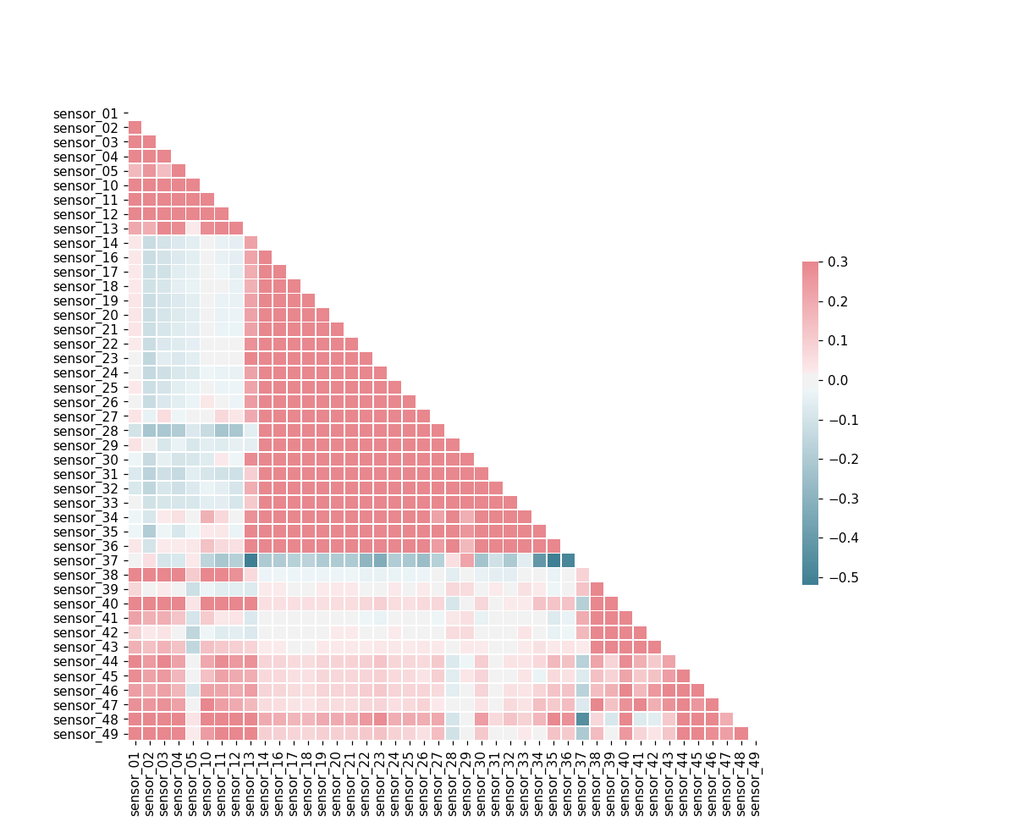

```python
#Copied from: https://seaborn.pydata.org/examples/many_pairwise_correlations.html

# Compute the correlation matrix
corr = df.corr()

# Generate a mask for the upper triangle
mask = np.triu(np.ones_like(corr, dtype=np.bool))

# Set up the matplotlib figure
f, ax = plt.subplots(figsize=(11, 9))

# Generate a custom diverging colormap
cmap = sns.diverging_palette(220, 10, as_cmap=True)

# Draw the heatmap with the mask and correct aspect ratio
sns.heatmap(corr, mask=mask, cmap=cmap, vmax=.3, center=0,
            square=True, linewidths=.5, cbar_kws={"shrink": .5})
```

- Initially nothing majorly correlated, but there do seem to be groupings of sorts

### Standardize / normalize values of each timeseries:

```python
# df.fillna()
```

```python
## Optionally do it for all sensors:
#####
df.iloc[:,:-1] = StandardScaler().fit_transform(df.iloc[:,:-1])
```

### Misc:

```python
print(df.shape)
list(zip(df.isna().sum(),df.dtypes))
```

```
(220320, 45)
```

```
[(369, dtype('float64')),
 (19, dtype('float64')),
 (19, dtype('float64')),
 (19, dtype('float64')),
 (19, dtype('float64')),
 (19, dtype('float64')),
 (19, dtype('float64')),
 (19, dtype('float64')),
 (19, dtype('float64')),
 (21, dtype('float64')),
 (31, dtype('float64')),
 (46, dtype('float64')),
 (46, dtype('float64')),
 (16, dtype('float64')),
 (16, dtype('float64')),
 (16, dtype('float64')),
 (41, dtype('float64')),
 (16, dtype('float64')),
 (16, dtype('float64')),
 (36, dtype('float64')),
 (20, dtype('float64')),
 (16, dtype('float64')),
 (16, dtype('float64')),
 (72, dtype('float64')),
 (261, dtype('float64')),
 (16, dtype('float64')),
 (68, dtype('float64')),
 (16, dtype('float64')),
 (16, dtype('float64')),
 (16, dtype('float64')),
 (16, dtype('float64')),
 (16, dtype('float64')),
 (27, dtype('float64')),
 (27, dtype('float64')),
 (27, dtype('float64')),
 (27, dtype('float64')),
 (27, dtype('float64')),
 (27, dtype('float64')),
 (27, dtype('float64')),
 (27, dtype('float64')),
 (27, dtype('float64')),
 (27, dtype('float64')),
 (27, dtype('float64')),
 (27, dtype('float64')),
 (0, dtype('O'))]
```

# Init data exploration:

```python
df.columns
```

```
Index(['sensor_01', 'sensor_02', 'sensor_03', 'sensor_04', 'sensor_05',
       'sensor_10', 'sensor_11', 'sensor_12', 'sensor_13', 'sensor_14',
       'sensor_16', 'sensor_17', 'sensor_18', 'sensor_19', 'sensor_20',
       'sensor_21', 'sensor_22', 'sensor_23', 'sensor_24', 'sensor_25',
       'sensor_26', 'sensor_27', 'sensor_28', 'sensor_29', 'sensor_30',
       'sensor_31', 'sensor_32', 'sensor_33', 'sensor_34', 'sensor_35',
       'sensor_36', 'sensor_37', 'sensor_38', 'sensor_39', 'sensor_40',
       'sensor_41', 'sensor_42', 'sensor_43', 'sensor_44', 'sensor_45',
       'sensor_46', 'sensor_47', 'sensor_48', 'sensor_49', 'machine_status'],
      dtype='object')
```

### How are the labels distributed?

```python
display(df.machine_status.value_counts())
print('\n\nThe same in percentages :')
df.machine_status.value_counts(normalize=True)*100
```

```
NORMAL        205836
RECOVERING     14477
BROKEN             7
Name: machine_status, dtype: int64
```

```
The same in percentages :
```

```
NORMAL        93.425926
RECOVERING     6.570897
BROKEN         0.003177
Name: machine_status, dtype: float64
```

- Broken status is extremely rare it only occurs 0.003% of the time!
- Initial thoughts are to try and visually demontrate how a broken status happens on a device and try and figure out a pattern.
- I think a standard ML will struggle to identify broken status on such an unbalanced dataset

```python
df[df.machine_status == 'BROKEN'].isna().sum(axis=1)
```

```
timestamp
2018-04-12 21:55:00    0
2018-04-18 00:30:00    0
2018-05-19 03:18:00    0
2018-05-25 00:30:00    0
2018-06-28 22:00:00    0
2018-07-08 00:11:00    0
2018-07-25 14:00:00    0
dtype: int64
```

- Whenever machine_status == 'BROKEN' there does seems to be incoming data!

### Are 'BROKEN' labels always followed by 'RECOVERING' and preceded by 'Normal'?

```
(220320, 1)
['BROKEN' 'NORMAL' 'RECOVERING']
```

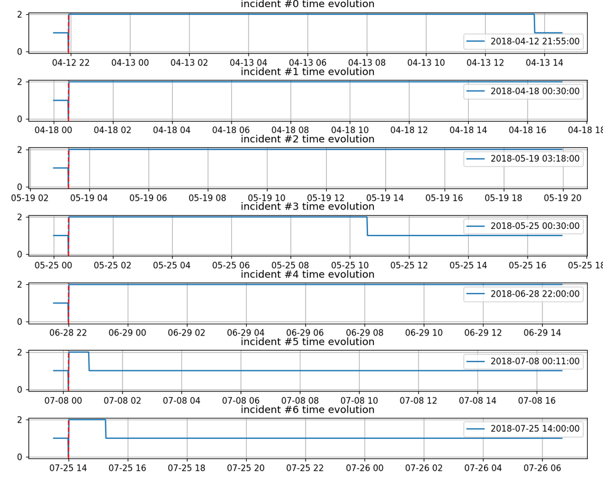

```python
idx = df[df.machine_status == 'BROKEN'].index

# dt = 2400
dt_m = 30
dt_p = 1000
df_labels= df[['machine_status']].copy()
print(df_labels.shape)

encoder = LabelEncoder().fit(df_labels[['machine_status']])
print(encoder.classes_)

df_labels['machine_status'] = encoder.transform(df_labels[['machine_status']])

df_labels.head()

fig,ax = plt.subplots(7,1,figsize=(10,8))
fig.tight_layout()

for i,x in enumerate(idx):

    t_m_dt = x - datetime.timedelta(minutes = dt_m)
    t_p_dt = x + datetime.timedelta(minutes = dt_p)

    df_plot = df_labels.loc[t_m_dt:t_p_dt,['machine_status']].copy()

    ax[i].plot(df_plot,label=x)
    ax[i].axvline(idx[i],linestyle='--',color='r')
    ax[i].set_title(f'incident #{i} time evolution')
    ax[i].legend()
    ax[i].grid()
```

```python
shifted = df_labels.machine_status.shift(-1)
orig = df_labels.machine_status

condition = (orig !=2) & (shifted == 2)
np.where(condition,1,0).sum()
```

```
7
```

### How does a particular sensor behave around the machine_status == 'broken' timestamps?

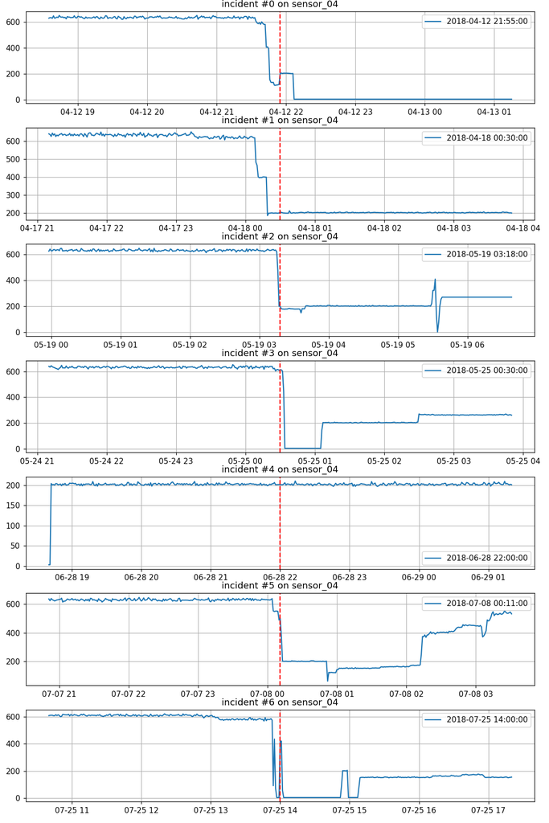

```python
idx = df[df.machine_status == 'BROKEN'].index

dt = 200
sensor= 'sensor_04'
fig,ax = plt.subplots(7,1,figsize=(10,15))
fig.tight_layout()
for i,x in enumerate(idx):

    t_m_dt = x - datetime.timedelta(minutes = dt)
    t_p_dt = x + datetime.timedelta(minutes = dt)

    df_plot = df.loc[t_m_dt:t_p_dt,[sensor]].copy()

    ax[i].plot(df_plot,label=x)
    ax[i].axvline(idx[i],linestyle='--',color='r')
    ax[i].set_title(f'incident #{i} on {sensor}')
    ax[i].legend()
    ax[i].grid()
```

### How does each sensor behave in relation to other sensors during a Broken status?

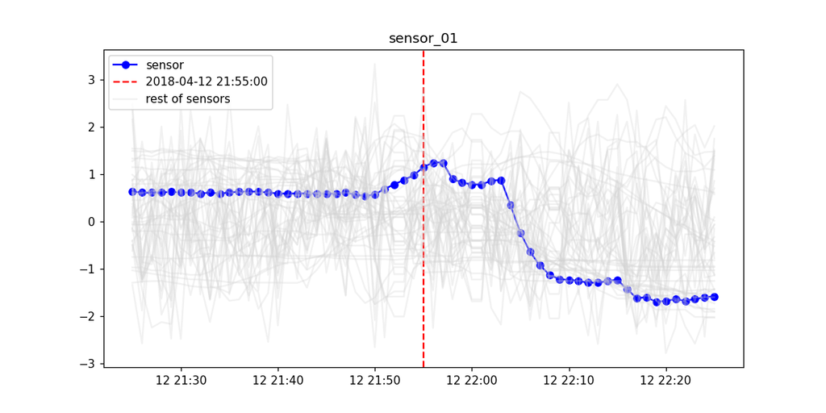

```python
# one sensor

idx = df[df.machine_status == 'BROKEN'].index

dt = 30
t_m_dt = idx[0] - datetime.timedelta(minutes = dt)
t_p_dt = idx[0] + datetime.timedelta(minutes = dt)

df_plot = df.loc[t_m_dt:t_p_dt,:].copy()
df_plot = df_plot.iloc[:,:-1]
df_plot.iloc[:,:] = StandardScaler().fit_transform(df_plot)
# display(df_plot.columns)

### Make plots:
# fig,ax = plt.subplots(nrows=7,ncols=7,figsize=(10,5))
fig,ax = plt.subplots(nrows=1,ncols=1,figsize=(10,5))
# fig.tight_layout()

sensor= 'sensor_01'
ax.plot(df_plot[[sensor]],'b-o',label= 'sensor')
ax.axvline(idx[0],linestyle='--',color='r',label = str(idx[0]))

rest = [x for x in df_plot.columns if x != sensor]
for s in rest:
    ax.plot(df_plot[[s]],'-',color='lightgrey',alpha=0.3)

#dummy for legend:
ax.plot([],[],'-',color='lightgrey',alpha=0.3,label='rest of sensors')

ax.set_title(sensor)
ax.legend(loc='upper left')
```

[figure not shown]

```python
# all sensors

idx = df[df.machine_status == 'BROKEN'].index
incident = idx[2]

dt = 120
t_m_dt = incident - datetime.timedelta(minutes = dt)
t_p_dt = incident + datetime.timedelta(minutes = dt)
# t_m_dt = incident - datetime.timedelta(hours = dt)
# t_p_dt = incident + datetime.timedelta(hours = dt)



df_plot = df.loc[t_m_dt:t_p_dt,:].copy()
df_plot = df_plot.iloc[:,:-1]
df_plot.iloc[:,:] = StandardScaler().fit_transform(df_plot)
# display(df_plot.columns)

### Make plots:
n_rows = 9
n_cols = 5

fig,ax = plt.subplots(nrows=n_rows,ncols=n_cols,figsize=(12,14), sharex=True, sharey=True)
# fig.tight_layout()

for i,sensor in enumerate(df_plot.columns):

    row= i // n_cols
    col= i % n_cols
#     print(row,col,i,sensor)

#     rest = [x for x in df_plot.columns if x != sensor]
#     for s in rest:
#         ax[row][col].plot(df_plot[[s]],'-',color='lightgrey',alpha=0.3)

    ax[row][col].plot(df_plot[[sensor]],'b-o',label= f'{sensor} row{row},col{col} ')
    ax[row][col].axvline(incident,linestyle='--',color='r',label = 'ts of incident')
    ax[row][col].set_title(sensor)

    #dummy plot
    ax[row][col].plot([],[],'-',color='lightgrey',alpha=0.3,label='rest of sensors')
    ax[row][col].tick_params(labelrotation=45)

ax[-1][-1].tick_params(labelrotation=45)
fig.suptitle(f'Broken incident timestamp {idx[-1]} \n')
fig.tight_layout()
```

- Similar to the correlation plot there seem to be underlying groupings in the sensors. For example the sensors 1-13 , 14-36/37 and 38-49 exhibit "similar" patterns.

### Plots:

```python
df.columns
```

```
Index(['sensor_01', 'sensor_02', 'sensor_03', 'sensor_04', 'sensor_05',
       'sensor_10', 'sensor_11', 'sensor_12', 'sensor_13', 'sensor_14',
       'sensor_16', 'sensor_17', 'sensor_18', 'sensor_19', 'sensor_20',
       'sensor_21', 'sensor_22', 'sensor_23', 'sensor_24', 'sensor_25',
       'sensor_26', 'sensor_27', 'sensor_28', 'sensor_29', 'sensor_30',
       'sensor_31', 'sensor_32', 'sensor_33', 'sensor_34', 'sensor_35',
       'sensor_36', 'sensor_37', 'sensor_38', 'sensor_39', 'sensor_40',
       'sensor_41', 'sensor_42', 'sensor_43', 'sensor_44', 'sensor_45',
       'sensor_46', 'sensor_47', 'sensor_48', 'sensor_49', 'machine_status'],
      dtype='object')
```

#### Taking a look at an individual timeseries:

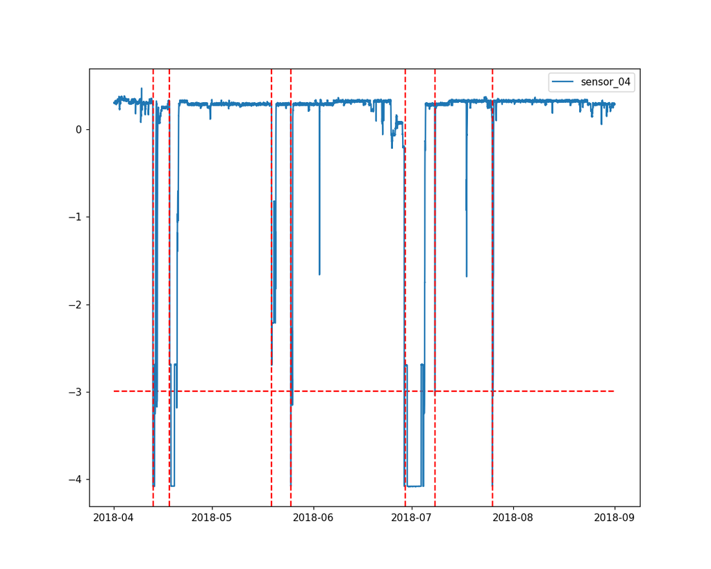

```
(220320,)
(220320,)
-0.0010563758228277352 0.9984138553685051
```

```python
plt.figure(figsize = (10,8))

sensor_name = 'sensor_04'
# sensor_name = 'sensor_41'
val = StandardScaler().fit_transform(df[[sensor_name]].values)
val = pd.Series(val.ravel()).fillna(0)
val = val.rolling(window=60,center=True).median()

print(df.index.shape)
print(val.shape)

plt.plot(df.index,val,label = sensor_name)

idx = df[df.machine_status == 'BROKEN'].index
for x in idx:
    plt.axvline(x,ymax=12,linestyle='--',color='r')

# idx = df[df.machine_status == 'RECOVERING'].index[5::30]
# for x in idx:
#     plt.axvline(x,ymax=12,linestyle='--',color='g')

m = pd.Series(val.ravel()).fillna(0).mean()
s = pd.Series(val.ravel()).fillna(0).std()
print(m,s)

plt.hlines(m-3*s, df.index[0], df.index[-1], colors='r', linestyles='--')
# plt.hlines(df.index,[ for x in range(len(val))],'--',label='3 sigma')
plt.legend()
```

#### FFT spectrum:

```python
# TODO
```

#### Testing spectral residual idea:

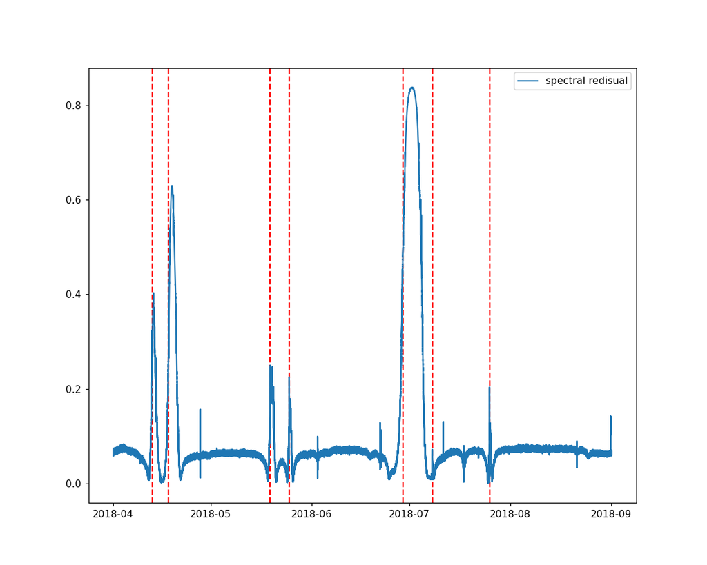

```
[43.75200276 43.75200276 48.26590276 ... 35.30290608 45.02510276
 49.19180276]
```

```python
#more on this: https://arxiv.org/pdf/1906.03821.pdf
# and here: http://citeseerx.ist.psu.edu/viewdoc/download?doi=10.1.1.125.5641&rep=rep1&type=pdf

plt.figure(figsize = (10,8))

sensor_name = 'sensor_04'
val = StandardScaler().fit_transform(df[[sensor_name]].values)
val = pd.Series(val.ravel()).fillna(0)
val = val.rolling(window=60,center=True).median()

# plt.plot(df.index,val,label = sensor_name)

idx = df[df.machine_status == 'BROKEN'].index
for x in idx:
    plt.axvline(x,ymax=12,linestyle='--',color='r')

#### Spectral residual:
sr_ts = df[sensor_name].copy().fillna(0).values
sr_ts -= sr_ts.mean()
print(sr_ts)

fft = np.fft.fft(sr_ts)
amp = np.abs(fft)
log_amp = np.log(amp)
phase = np.angle(fft)

win_size = 600
conv_amp = np.array([1/win_size for x in range(win_size)])
ma_log_amp = np.convolve(log_amp, conv_amp, 'same')

res_amp = log_amp - ma_log_amp
sr = np.abs(np.fft.ifft(np.exp(res_amp + 1j * phase)))

plt.plot(df.index,sr,label = 'spectral redisual')

# m = pd.Series(val.ravel()).fillna(0).mean()
# s = pd.Series(val.ravel()).fillna(0).std()
# print(m,s)

# plt.hlines(m-3*s, df.index[0], df.index[-1], colors='r', linestyles='--')
# # plt.hlines(df.index,[ for x in range(len(val))],'--',label='3 sigma')

plt.legend()
```

- this transformation / spike detection looks promising ,but would require more time to investigate

#### Further plots:

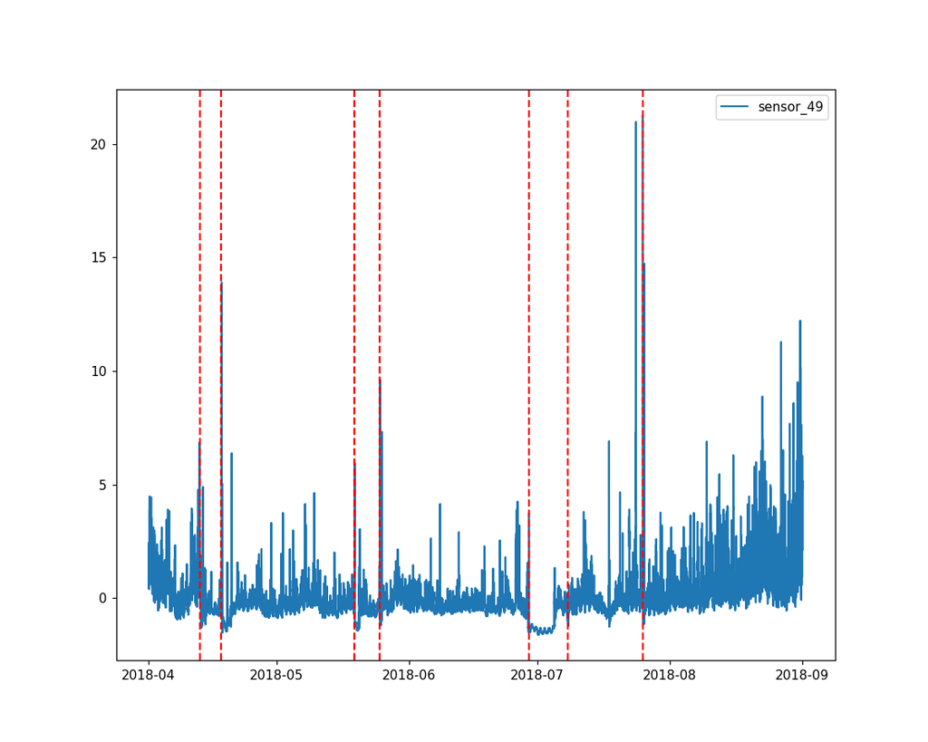

```python
plt.figure(figsize = (10,8))

sensor_name = 'sensor_49'
val = StandardScaler().fit_transform(df[[sensor_name]].values)

kernel = np.array([-1,1])
val_diff = np.correlate(val.ravel(),kernel,mode='same')

plt.plot(df.index,val,label = sensor_name)
# plt.plot(df.index,val_diff,label = sensor_name + '_diff')

idx = df[df.machine_status == 'BROKEN'].index
for x in idx:
    plt.axvline(x,ymax=12,linestyle='--',color='r')

plt.legend()
```

```python
df.iloc[:,:-1].mean(axis=1)
```

```
timestamp
2018-04-01 00:00:00    278.944728
2018-04-01 00:01:00    278.944728
2018-04-01 00:02:00    282.829332
2018-04-01 00:03:00    283.202554
2018-04-01 00:04:00    282.038153
                          ...
2018-08-31 23:55:00    317.638471
2018-08-31 23:56:00    316.751150
2018-08-31 23:57:00    317.097436
2018-08-31 23:58:00    316.077552
2018-08-31 23:59:00    317.198583
Length: 220320, dtype: float64
```

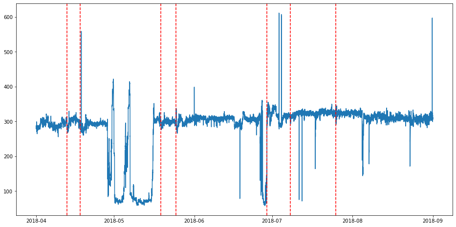

```python
plt.figure(figsize = (16,8))
plt.plot(df.iloc[:,:-1].mean(axis=1))
idx = df[df.machine_status == 'BROKEN'].index
for x in idx:
    plt.axvline(x,ymax=12,linestyle='--',color='r')
```

# Simple Model

- simple thresholding based on standard deviation of signal.
- sensor #4 seems like an ideal candidate BROKEN status is nearly always followed by a 3*sigma swing in signal values.
- split timeseries into 2 parts, train and test. Use train set to calculate standard deviation (sigma)
- Locate crossings of the threshold (only do it when derivative is negative).
- will generate many false positives, ie Model says it is broken, yet it is actually in recovery phase.
- on the plus side few false negatives (hopefully)

## Train phase:

```python
def ThresholdCrossings(x):

    ## Detect threshold crossings:
    signal_sign_diff = np.diff(np.sign(signal_crossing))

    #zero crossings, only checking for positive to negative
    crossings = np.where(signal_sign_diff < 0,signal_sign_diff,0)
    crossing_idx = crossings.nonzero()[0]

    return crossing_idx
```

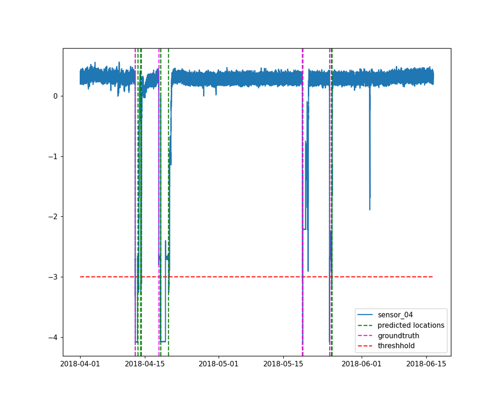

```python
## Split train / test
split_idx = df.shape[0] // 2

sensor_name = 'sensor_04'
signal = StandardScaler().fit_transform(df[[sensor_name]].values)
signal = pd.Series(signal.ravel()).fillna(0)

plt.figure(figsize=(10,8))

plt.plot(df.index[:split_idx],signal.iloc[:split_idx],label = sensor_name)

## Plot threshold
sigma_train = signal.std()
plt.hlines(-3*sigma_train, df.iloc[:split_idx].index[0], df.iloc[:split_idx].index[-1], colors='r', linestyles='--',label = 'threshhold')


## Detect threshold crossings:
signal_crossing = signal.iloc[:split_idx] + 3*sigma_train
crossing_idx = ThresholdCrossings(signal_crossing)

## Plot predictions
for c in crossing_idx:
    plt.axvline(df.index[c],ymax=12,linestyle='--',color='g')
plt.plot([],[],linestyle='--',color='g',label = 'predicted locations')

### Plot ground truth
idx = df[df.machine_status == 'BROKEN'].index
for x in idx[:-3]:
    plt.axvline(x,ymax=12,linestyle='--',color='magenta')
#dummy plot()
plt.plot([],[],linestyle='--',color='magenta',label = 'groundtruth')

plt.legend()
```

## Test Phase:

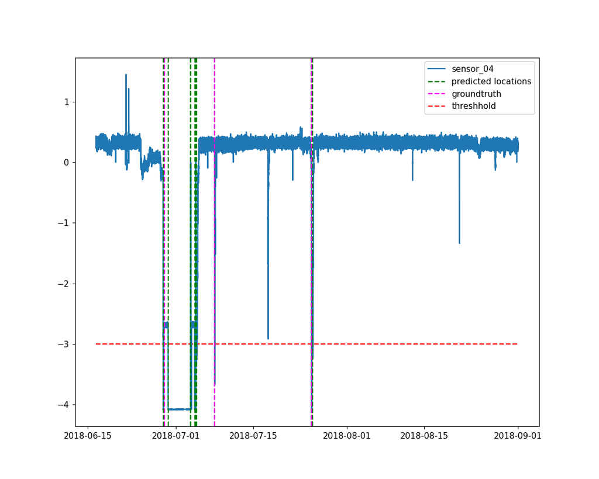

```python
plt.figure(figsize=(10,8))

plt.plot(df.index[split_idx:],signal.iloc[split_idx:],label = sensor_name)

## Plot threshold
plt.hlines(-3*sigma_train, df.iloc[split_idx:].index[0], df.iloc[split_idx:].index[-1], colors='r', linestyles='--',label = 'threshhold')

## Detect threshold crossings:
signal_crossing = signal.iloc[split_idx:] + 3*sigma_train
crossing_idx = ThresholdCrossings(signal_crossing)

## Plot predictions
for c in crossing_idx:
    plt.axvline(df.iloc[split_idx:].index[c],ymax=12,linestyle='--',color='g')
plt.plot([],[],linestyle='--',color='g',label = 'predicted locations')

### Plot ground truth
idx = df[df.machine_status == 'BROKEN'].index
for x in idx[4:]:
    plt.axvline(x,ymax=12,linestyle='--',color='magenta')
#dummy plot()
plt.plot([],[],linestyle='--',color='magenta',label = 'groundtruth')

plt.legend()
```

## TODO:

```
- quantify predictions "accuracy"
- Something similar to F1? Or Recall (minimize false negatives)
- improve threshold? dynamic thresholding by incorporating more sensor data?
```

# Further ideas:

- Filter signals
- Use more of the sensors' data
- Broken status seems to coincide with swings in signal values in many of the sensors. Use this for feature generation and then somhow try and aggregate them together.

## Some questions:

- How accurate in time do the predictions need to be? is it okay to be 5/15/30 minutes late?

# Misc

```python
## TEsting zero crossing detection:

a = [1, 2, 1, 1, -3, -4, 7, 8, 9, 10, -2, 1, -3, 5, 6, 7, -10]

a_sign_diff = np.diff(np.sign(a))
#zero crossings, only checking for positive to negative
crossings = np.where(a_sign_diff < 0,a_sign_diff,0)
crossing_idx = crossings.nonzero()

print('sign:', np.sign(a))
print('sign diff:', np.diff(np.sign(a)))
print('crossings:', crossings,)

print('where', np.where(np.diff(np.sign(a))))
print('crossover indices', crossing_idx )


# zero_crossings = numpy.where(numpy.diff(numpy.sign(a)))[0]
```

```
sign: [ 1  1  1  1 -1 -1  1  1  1  1 -1  1 -1  1  1  1 -1]
sign diff: [ 0  0  0 -2  0  2  0  0  0 -2  2 -2  2  0  0 -2]
crossings: [ 0  0  0 -2  0  0  0  0  0 -2  0 -2  0  0  0 -2]
where (array([ 3,  5,  9, 10, 11, 12, 15]),)
crossover indices (array([ 3,  9, 11, 15]),)
```